# Mar 5 Class FAQ

Elgar Teo

March 06, 2021

You should take the lecture first before reading this FAQ, since some of the examples below are borrowed from the in-class activities.

## Why is the console not responding?

Some of you encountered a problem of an unresponsive console in RStudio that no matter what you type in the code just does not run:

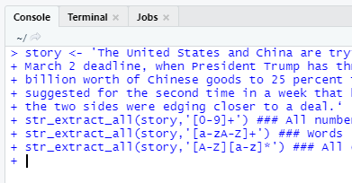

Note the `+` sign in the console. It indicates that it is expecting more input to an unfinished command. It is actually a feature of R that allows you to break down a command into several lines and input them one by one:

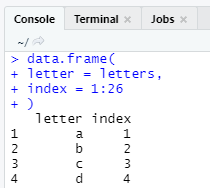

Therefore, if there is a `+` sign in the console instead of the usual `>` sign, it means that you have entered an unfinished command. But sometimes you may encounter this sign unintentionally. The most common reason is the presence of a wrong quotation mark (as mentioned [previously](https://elgarteo.github.io/JMSC6116-2020/feb5.html#%22,_',_%E2%80%98%E2%80%99_and_%E2%80%9C%E2%80%9D). In the lecture slides, one line of the code uses the wrong close quotation mark `‘` instead of the usual `'` (thanks to auto-correct). Since `‘` does not carry any meaning and is only treated as any other normal character in a string, the string is unfinished and R expects more input as part of the string until there is a proper `'`. To exit this state, simply press the Esc key.

## `\n`

You may have noticed that when you copy a code off the lecture slides directly and run it in R, there are some `\n` in the string. They are special characters to preserve formatting in a string such as line skip and tab space:

```r
string <- "This is the first line.
This is a new line."
string
```

```
## [1] "This is the first line.\nThis is a new line."
```

A line of code in the lecture slides is split into several lines due to space constraint, and thus when it is directly pasted in R the line skips are recorded as part of the string. You can use regular expression to remove them:

```r
gsub("\n", " ", string)
```

```
## [1] "This is the first line. This is a new line."
```

If you want to view the formatted version of the string, you can use `cat()`:

```r
cat(string)
```

```
## This is the first line.
## This is a new line.
```

## Unicode characters

Unicode is an encoding standard that is widely used in computer systems. It is sometimes referred to as UTF-8, which is the most popular version of Unicode. Unicode covers almost every character in almost every language in the world, and each character is represented by a code in the Unicode character set, which can be used in R with a preceding `\U`. For example, the Unicode for the Yuan sign is U+00A5:

```r
"\U00A5"
```

```
## [1] "¥"
```

### Emoji

Emojis fall in the range of U+1F600 to U+1F64F in the Unicode character set. For instance, the Unicode for 😂 is U+1F602:

```r
"\U1F602"
```

```
## [1] "😂"
```

Note that direct printing of Unicode in R is not well-supported, especially on Windows. In such cases, you can use `cat()` to force R to render the correct character:

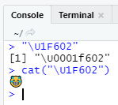

Since we know the range of the Unicode for emojis, we can use regular expression to work with emojis:

```r
tweets <- search_tweets("emoji")
head(grep("[\U1F600-\U1F64F]", tweets$text, value = TRUE)) # find out emoji-containing tweets
```

```
## [1] "@taevocii mann 😭🌚\n☁️,💿, I like your @ (emoji not visible)"
## [2] "Efek captionnya hasil copas-an tweet yang di hapus jadi emoji fire nya ga keluar 😭🤣 https://t.co/YT7ae3lWBk"
## [3] "my friend sent me this an hour ago saying: “ this emoji 😐 literally looks like ur irl face. “ and i can agree👍"
## [4] "📰 20210306 Taehyung for 3PM KST🇰🇷/1PM VN🇻🇳🙏🏻\n\n1 https://t.co/tq8ahIXAI3\n2 https://t.co/GbKetuLnTl\n3 https://t.co/EXjj0lZme8\n4 https://t.co/fJAuJZL7o0\n5 https://t.co/XS6taUVv94  \n\n☑️ NHẤP VÀO EMOJI. React, Đề xuất , chia sẻ lên FB , twt , blog Naver\n☑️LIKE, RECOMMEND &amp; SHARE http…
## [5] "@clarabarrettoo obrigado por aderir o emoji😀😀"
## [6] "📰 20210306 Taehyung for 3PM KST🇰🇷/1PM VN🇻🇳🙏🏻\n\n1 https://t.co/tq8ahIXAI3\n2 https://t.co/GbKetuLnTl\n3 https://t.co/EXjj0lZme8\n4 https://t.co/fJAuJZL7o0\n5 https://t.co/XS6taUVv94  \n\n☑️ NHẤP VÀO EMOJI. React, Đề xuất , chia sẻ lên FB , twt , blog Naver\n☑️LIKE, RECOMMEND &amp; SHARE http…
```

```r
table(unlist(str_extract_all(tweets$text, "[\U1F600-\U1F64F]"))) # extract  and count emojis in tweets
```

```
##
## 😀 😂 😄 😆 😏 😐 😑 😒 😭 😮 🙎 🙏
##  4  9  1  2  2  1  1  1  2  1  1  3
```

### Chinese and other Asian languages

You can use Chinese in regular expression:

```r
string <- c("子弹射中大腿", "就读于中大传播系", "传说中大腿月瘦13cm", "中大博士在读")
grep("中大[^腿]", string) # find out which string refers to the correct 中大
```

```
## [1] 2 4
```

Or any other Korean language long as it’s supported by your system:

```r
head(string) # Korean tweets
```

[output not shown]

```r
head(gsub("[ㄱ-ㅎ]|[ㅏ-ㅣ]", "", string)) # remove shorthands that are based on 자음 and 모음
```

```
## [1] "근데 저도 20대 때 많이 누워 있었어요 \n이말이 왤케 좋지  https://t.co/5SEFrOKNJp"
## [2] "@N1JIK0N 케잌이랑꽃"
## [3] "@yommm___ 야 . "
## [4] "@GATE_OF_UTOPIA 몽게몽게  !"
## [5] "@GATE_OF_UTOPIA 이걸 좋은갠봇님 만나세요 를 해야되나 \n\n 오시면 행복한 시간보내셔요\n\n"
## [6] "@youcansmoke 아 시바\n\n\n\n\n\n\n\n\n\n\n\n\n"
```

The Unicode ranges for common Asian languages are as follows:

- Chinese: U+4E00 to U+9FFF
- Korean: U+AC00 to U+D7A3
- Japanese: U+3040 to U+30FF

Therefore, it is possible to use the Unicode range to determine the language of a string:

```r
string <- c("您好", "안녕하세요", "こんにちは")
grep("[\U4E00-\U9FFF]", string) # Chinese
```

```
## [1] 1
```

```r
grep("[\UAC00-\UD7A3]", string) # Korean
```

```
## [1] 2
```

```r
grep("[\U3040-\U30FF]", string) # Japanese
```

```
## [1] 3
```

But be aware that the range for Chinese characters also includes Japanese Kanji:

```r
grepl("[\U4E00-\U9FFF]", "日産自動車、営業益45%減")
```

```
## [1] TRUE
```

Again, R cannot display Chinese characters properly on some systems. Again, you use `cat()` if you need to inspect the characters:

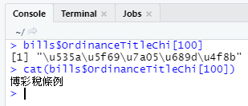